### Author : Indumathi Pandiyan

# Project 2: Supervised Learning

This is the second Project in AIML PGP course in Great Learning for the concept of Supervised Learning

### Duration of the Project : 2 weeks

#### Date: 14-11-2021 to 28-01-2021

# Part 1

**Context**:Medical research university X is undergoing a deep research on patients with certain conditions. University has an internal AI team. Due to confidentiality the patient’s details and the conditions are masked by the client by providing different datasets to the AI team for developing a AIML model which can predict the condition of the patient depending on the received test results.

**Data Description:** The data consists of biomechanics features of the patients according to their current conditions. Each patient is represented in the data set by six biomechanics attributes derived from the shape and orientation of the condition to their body part.

1. P_incidence
2. P_tilt
3. L_angle
4. S_slope
5. P_radius
6. S_degree
7. Class

**Project Objective:**

Demonstrate the ability to fetch, process and leverage data to generate useful predictions by training Supervised Learning algorithms.

Hence the purpose of this project is to predict the conditions of patients based on the biomechanic features through Supervised learning algorithms.

## 1. Data Understanding

**a.Read all the 3 CSV files as DataFrame and store them into 3 separate variables**

Import all the required Libraries

```python
import pandas as pd
import numpy as np
import matplotlib.pyplot as plt
import seaborn as sns
from scipy.stats import zscore
from sklearn.model_selection import train_test_split
from sklearn.neighbors import KNeighborsClassifier
from sklearn.metrics import mean_squared_error, confusion_matrix, classification_report, roc_curve, precision_recall_curve, roc_auc_score, accuracy_score
#
# Ignore warnings
import warnings
warnings.filterwarnings("ignore")
#
# To enable plotting graphs in Jupyter notebook
%matplotlib inline
```

```python
import warnings
warnings.simplefilter("ignore")
```

```python
typeH=pd.read_csv("Type_H.csv")
```

```python
typeS=pd.read_csv("Type_S.csv")
```

```python
normal=pd.read_csv("Normal.csv")
```

**Comments:** The 3 csv files are been read and stored into 3 different variables typeH, typeS and normal respectively.

**b. Print Shape and columns of all the 3 DataFrames**

```python
typeH.shape
```

```
(60, 7)
```

```python
typeS.shape
```

```
(150, 7)
```

```python
normal.shape
```

```
(100, 7)
```

**C.Compare Column names of all the 3 DataFrames and clearly write observations**

```python
typeH.columns
```

```
Index(['P_incidence', 'P_tilt', 'L_angle', 'S_slope', 'P_radius', 'S_Degree',
       'Class'],
      dtype='object')
```

```python
typeS.columns
```

```
Index(['P_incidence', 'P_tilt', 'L_angle', 'S_slope', 'P_radius', 'S_Degree',
       'Class'],
      dtype='object')
```

```python
normal.columns
```

```
Index(['P_incidence', 'P_tilt', 'L_angle', 'S_slope', 'P_radius', 'S_Degree',
       'Class'],
      dtype='object')
```

#### Comments

1. All 3 datasets have 7 columns [P_incidence, P_tilt, L_angle, S_slope, P_radius, S_Degree,and Class]
2. typeH, typeS and normal dataset has 60,150 and 100 rows respectively

All three data frames has following **column names.**

1. P_incidence
2. P_tilt
3. L_angle
4. S_slope
5. P_radius
6. S_Degree
7. Class

All three data frames has following column names. All these dataframes has the above list of columns and categorized as Type_H, Type_S and Normal. The features like P_tilt, P_angle , P_Slope looks to be like the angles P_radius would represent the raidus of the cell

**d. Print DataTypes of all the 3 DataFrames.**

```python
typeH.dtypes
```

```
P_incidence    float64
P_tilt         float64
L_angle        float64
S_slope        float64
P_radius       float64
S_Degree       float64
Class           object
dtype: object
```

```python
typeS.dtypes
```

```
P_incidence    float64
P_tilt         float64
L_angle        float64
S_slope        float64
P_radius       float64
S_Degree       float64
Class           object
dtype: object
```

```python
normal.dtypes
```

```
P_incidence    float64
P_tilt         float64
L_angle        float64
S_slope        float64
P_radius       float64
S_Degree       float64
Class           object
dtype: object
```

**Comments:** All the columns of all the 3 dataset has float data type for all the columns except the "Class" which would be target varible in our analysis

**e.Observe and share variation in ‘Class’ feature of all the 3 DataFrames.**

```python
typeH['Class'].unique()
```

```
array(['Type_H', 'type_h'], dtype=object)
```

```python
typeH['Class'].value_counts()
```

```
Type_H    37
type_h    23
Name: Class, dtype: int64
```

```python
typeS['Class'].unique()
```

```
array(['Type_S', 'tp_s'], dtype=object)
```

```python
typeS['Class'].value_counts()
```

```
Type_S    133
tp_s       17
Name: Class, dtype: int64
```

```python
normal['Class'].unique()
```

```
array(['Normal', 'Nrmal'], dtype=object)
```

```python
normal['Class'].value_counts()
```

```
Normal    73
Nrmal     27
Name: Class, dtype: int64
```

**Observations on Data Understanding**

The 3 csv files has the biomechanic details of patients with 3 Classes typeH, TypeS and Normal.

- **`TypeH`** - has 60 datasets
- **`TypeS`** - has 150 datasets
- **`Normal`** - has 100 datasets

typeH dataframe has "Class" values Type_H or type_h

typeS dataframe has "Class" values Type_S and tp_s

normal dataframe has "Class" values Normal and Nrmal.

Essentially these 3 dataframes have the parameters which categorize as 3 Types namely typeH, typeS and Normal.

## 2.Data Preparation and Exploration

a. Unify all the variations in ‘Class’ feature for all the 3 DataFrames. [1 Marks] For Example: ‘tp_s’, ‘Type_S’, ‘type_s’ should be converted to ‘type_s’

b. Combine all the 3 DataFrames to form a single DataFrame [1 Marks] Checkpoint: Expected Output shape = (310,7)

c. Print 5 random samples of this DataFrame [1 Marks]

d. Print Feature-wise percentage of Null values. [1 Mark]

e. Check 5-point summary of the new DataFrame. [1 Mark]

**a. Unify all the variations in ‘Class’ feature for all the 3 DataFrames. [1 Marks] For Example: ‘tp_s’, ‘Type_S’, ‘type_s’ should be converted to ‘type_s’**

```python
# To replace multiple values with one
typeH['Class']=typeH['Class'].replace(['Type_H'], 'type_h')
typeH['Class'].value_counts()
```

```
type_h    60
Name: Class, dtype: int64
```

```python
typeS['Class']=typeS['Class'].replace(dict.fromkeys(['tp_s','Type_S'], 'type_s'))
typeS['Class'].value_counts()
```

```
type_s    150
Name: Class, dtype: int64
```

```python
normal['Class']=normal['Class'].replace(dict.fromkeys(['Normal','Nrmal'], 'normal'))
normal['Class'].value_counts()
```

```
normal    100
Name: Class, dtype: int64
```

**Comments:** The variations in the content of 'Class' feature is been unified as 3 types as follows

```
1.type_h
2.type_s
3.normal
```

**b. Combine all the 3 DataFrames to form a single DataFrame [1 Marks]**

Checkpoint: Expected Output shape = (310,7)

```python
#Names of the dataframes
frames = [typeH, typeS, normal]
#Combine all dataframes to a Single Dataframe
biomechanics = pd.concat(frames, axis=0)
biomechanics.shape
```

```
(310, 7)
```

**Comments:** The 3 dataframes of Shapes (60,7),(150,7),(100,7) are combined to one single dataframe biomechanics with Size 310,7

```python
biomechanics.head()
```

|  | P_incidence | P_tilt | L_angle | S_slope | P_radius | S_Degree | Class |
| --- | --- | --- | --- | --- | --- | --- | --- |
| 0 | 63.027817 | 22.552586 | 39.609117 | 40.475232 | 98.672917 | -0.254400 | type_h |
| 1 | 39.056951 | 10.060991 | 25.015378 | 28.995960 | 114.405425 | 4.564259 | type_h |
| 2 | 68.832021 | 22.218482 | 50.092194 | 46.613539 | 105.985135 | -3.530317 | type_h |
| 3 | 69.297008 | 24.652878 | 44.311238 | 44.644130 | 101.868495 | 11.211523 | type_h |
| 4 | 49.712859 | 9.652075 | 28.317406 | 40.060784 | 108.168725 | 7.918501 | type_h |

**c. Print 5 random samples of this DataFrame [1 Marks]**

To print the random sample of 5, random state = 1 ensures reproducing the same results

```python
biomechanics.sample(n=5, random_state=1)
```

|  | P_incidence | P_tilt | L_angle | S_slope | P_radius | S_Degree | Class |
| --- | --- | --- | --- | --- | --- | --- | --- |
| 18 | 67.412538 | 17.442797 | 60.144640 | 49.969741 | 111.123970 | 33.157646 | type_s |
| 34 | 63.026300 | 27.336240 | 51.605017 | 35.690060 | 114.506608 | 7.439870 | normal |
| 125 | 91.468741 | 24.508177 | 84.620272 | 66.960564 | 117.307897 | 52.623047 | type_s |
| 10 | 72.560702 | 17.385191 | 52.000000 | 55.175511 | 119.193724 | 32.108537 | type_s |
| 60 | 54.741775 | 12.095072 | 41.000000 | 42.646703 | 117.643219 | 40.382327 | type_s |

**d.Print Feature-wise percentage of Null values. [1 Mark]**

```python
 biomechanics.isnull().sum()
```

```
P_incidence    0
P_tilt         0
L_angle        0
S_slope        0
P_radius       0
S_Degree       0
Class          0
dtype: int64
```

```python
percent_missing = biomechanics.isnull().sum() * 100 / len(biomechanics)
missing_value_biomechanics = pd.DataFrame({'Feature Name': biomechanics.columns,
                                 'percent_missing': percent_missing})
print(missing_value_biomechanics)
```

```
            Feature Name  percent_missing
P_incidence  P_incidence              0.0
P_tilt            P_tilt              0.0
L_angle          L_angle              0.0
S_slope          S_slope              0.0
P_radius        P_radius              0.0
S_Degree        S_Degree              0.0
Class              Class              0.0
```

**Comments**: No feature has null values

**e. Check 5-point summary of the new DataFrame. [1 Mark]**

**Comments:** Describe function in Python to see the Five Number Summary and other details of the data. describe() function gives us the count and mean of the features including the summary values.

```python
biomechanics.describe().T
```

|  | count | mean | std | min | 25% | 50% | 75% | max |
| --- | --- | --- | --- | --- | --- | --- | --- | --- |
| P_incidence | 310.0 | 60.496653 | 17.236520 | 26.147921 | 46.430294 | 58.691038 | 72.877696 | 129.834041 |
| P_tilt | 310.0 | 17.542822 | 10.008330 | -6.554948 | 10.667069 | 16.357689 | 22.120395 | 49.431864 |
| L_angle | 310.0 | 51.930930 | 18.554064 | 14.000000 | 37.000000 | 49.562398 | 63.000000 | 125.742385 |
| S_slope | 310.0 | 42.953831 | 13.423102 | 13.366931 | 33.347122 | 42.404912 | 52.695888 | 121.429566 |
| P_radius | 310.0 | 117.920655 | 13.317377 | 70.082575 | 110.709196 | 118.268178 | 125.467674 | 163.071041 |
| S_Degree | 310.0 | 26.296694 | 37.559027 | -11.058179 | 1.603727 | 11.767934 | 41.287352 | 418.543082 |

**5 Point summary (or) Five Number summary:** has following statistical quanties.  
**Median:** The middle value in the sample, also called the 50th percentile or the 2nd quartile.  
**1st Quartile:** The 25th percentile.  
**3rd Quartile:** The 75th percentile.  
**Minimum:** The smallest observation in the sample.  
**Maximum:** The largest observation in the sample.

**Use**:It can be used to describe the distribution of data samples for data with any distribution

#### Observation on information on the type of variable and min-max values

- **`P_incidence`**: numerical (continuous), quantitative, interval. Min P_incidence 26.14 and highest value 129.83
- **`P_tilt`**: numerical (continuous), quantitative, interval. Min P_tilt -6.55 and highest value 49.43
- **`L_angle`**: numerical (continuous), quantitative, interval. Min L_angle 14.00 and highest value 125.74
- **`S_slope`**: numerical (continuous), quantitative, interval. Min S_slope 13.36 and highest value 121.42.
- **`P_radius`**: numerical (continuous), quantitative, interval. Min P_radius 70.08 and highest value 163.07
- **`S_Degree`**: numerical (continuous), quantitative, interval. Min S_Degree -11.05 and highest value 418.54

#### Observation on Descriptive Statistics for the numerical variables

Descriptive statistics for the numerical variables (P_incidence, P_tilt, L_angle, S_Slope, P_radius, S_Degree)

- **`P_incidence`**: Range of Q1 to Q3 is between 46.430294 to 72.877696. Since the mean(60.496653) is greater than median(58.691038), we can say that P_incidence is right (positively) skewed.
- **`P_tilt`**: Range of Q1 to Q3 is between 10.667069 to 22.120395. Since the mean(17.542822) is greater than median(16.35768), we can say that P_tilt is right (positively) skewed.
- **`L_angle`**: Range of Q1 to Q3 is between 37.000000 to 63.000000. Since the mean(51.930930) is greater than median(49.562398), we can say that L_angle is right (positively) skewed.
- **`S_slope`**: nRange of Q1 to Q3 is between 33.347122 to 52.695888. Since the mean(42.953831) is greater than median(42.404912), is almost similar to median, we can say that S_slope is normally distributed.
- **`P_radius`**: Range of Q1 to Q3 is between 110.709196 to 125.467674. Since the mean(117.9206553) is lesser than median(118.268178), we can say that P_radius is left (negatively) skewed.
- **`S_Degree`**: Range of Q1 to Q3 is between 1.603727 to 41.287352. Since the mean(26.296694) is greater than median(11.767934), we can say that S_Degree is right (positively) skewed.

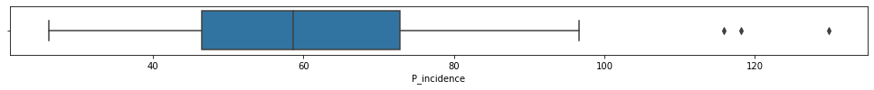

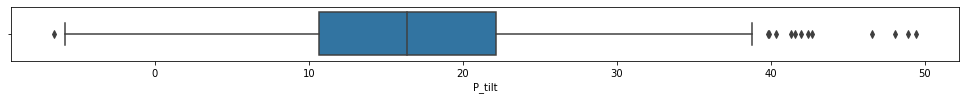

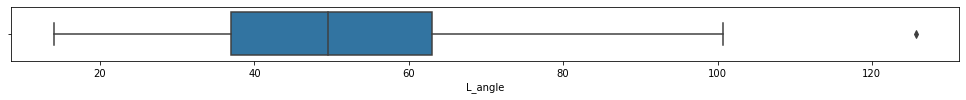

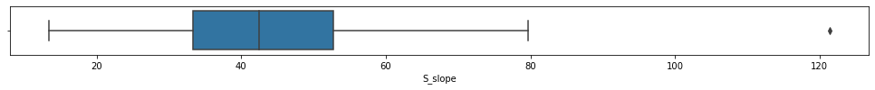

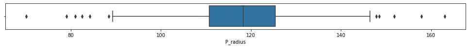

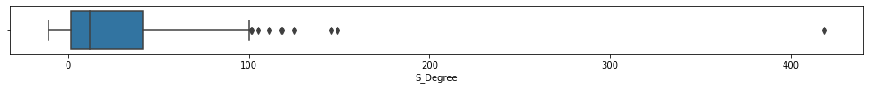

```python
import matplotlib.pyplot as plt
biomechanics1=biomechanics.select_dtypes(exclude=['object'])

for column in biomechanics1:
        plt.figure(figsize=(17,1))
        sns.boxplot(data=biomechanics1, x=column)
```

**Observation:** Box Plot helps to understand the distribution and 5 point summary in graphical way. From the box plot also the below conditions can be observed.

- **`S_Slope`**: Almost normally distributed
- **`P_incidence, P_tilt and L_angle`**: are slightly right skewed
- **`S_Degree`**: more positively skewed
- **`P_radius`**:slightly negatively (or) left skewed

## 3. Data Analysis

a. Visualize a heatmap to understand correlation between all features [2 Marks]

b. Share insights on correlation. [2 Marks]

i. Features having stronger correlation with correlation value.

ii. Features having weaker correlation with correlation value.

c. Visualize a pairplot with 3 classes distinguished by colors and share insights. [2 Marks]

d. Visualize a jointplot for ‘P_incidence’ and ‘S_slope’ and share insights. [2 Marks]

e. Visualize a boxplot to check distribution of the features and share insights. [2 Marks]

**a. Visualize a heatmap to understand correlation between all features [2 Marks]**

```python
corr =biomechanics.corr()
print(corr)
```

```
             P_incidence    P_tilt   L_angle   S_slope  P_radius  S_Degree
P_incidence     1.000000  0.629199  0.717282  0.814960 -0.247467  0.638743
P_tilt          0.629199  1.000000  0.432764  0.062345  0.032668  0.397862
L_angle         0.717282  0.432764  1.000000  0.598387 -0.080344  0.533667
S_slope         0.814960  0.062345  0.598387  1.000000 -0.342128  0.523557
P_radius       -0.247467  0.032668 -0.080344 -0.342128  1.000000 -0.026065
S_Degree        0.638743  0.397862  0.533667  0.523557 -0.026065  1.000000
```

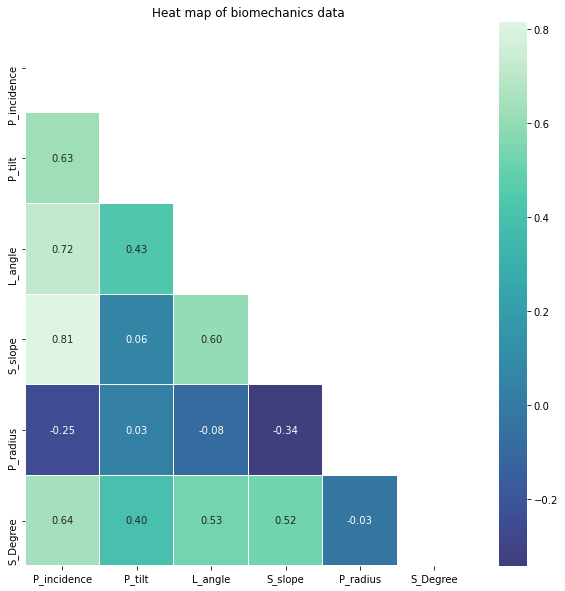

```python
fig, ax = plt.subplots(figsize=(10,10))
#sns.heatmap(df2.corr(), center=0, cmap='BrBG', annot=True)
# Generate a mask for the upper triangle
mask = np.triu(np.ones_like(corr, dtype=bool))
sns.heatmap(biomechanics.corr(), center=0, cmap='mako', annot=True, fmt='.2f', linewidths=0.05, mask=mask)
ax.set_title('Heat map of biomechanics data')
```

**Observation Correlation Between all the features**

- **`P_incidence`**:P_incidence is positively correlated with P_tilt,L_angle,S_slope and S_Degree. Among these P_incidence highly correlated with S_slope.P_incidence is negatively correlated with P_radius
- **`P_tilt`**:P_tilt is positively correlated with P_incidence, L_angle and S_Degree.P_tilt is less correlated with S_slope and P_radius
- **`L_angle`**:L_angle postiviely correlated with P_incidence,S_slope,S_Degree and P_tilt.Negatively correlated with P_radius
- **`S_Slope`**:S_slope positively correlated with P_incidence, L_angle, S_Degree.Very less correlated with P_tilt.S_slope negatively correlated with P_radius
- **`P_radius`**:P_radius less correlated with P_tilt.And negatively correlated with All other features of P_incidence, L_angle,S_slope and S_Degree
- **`S_Degree`**:S_Degree positively correlated with P_incidence, L_angle, S_Slope and P_tilt.S_Degree negatively correlated with P_radius

**b.Share insights on correlation. [2 Marks]**

**i.Features having stronger correlation with correlation value.**

#### Notes:

Considering 0.5 as threshold value below are highly correlated .  
The threshold greater than 0.5 or less than -0.5 are considered as strongly correlated.  
Greater than 0.5 is Strongly correleted positively.  
Lesser than -0.5 is Strongly correleted Negatively.

```python
# Filter for correlation value greater than 0.5
sort = corr.abs().unstack()
sort = sort.sort_values(kind = "quicksort", ascending = False)
sort[(sort > 0.5) & (sort < 1)]
```

```
P_incidence  S_slope        0.814960
S_slope      P_incidence    0.814960
L_angle      P_incidence    0.717282
P_incidence  L_angle        0.717282
S_Degree     P_incidence    0.638743
P_incidence  S_Degree       0.638743
P_tilt       P_incidence    0.629199
P_incidence  P_tilt         0.629199
S_slope      L_angle        0.598387
L_angle      S_slope        0.598387
S_Degree     L_angle        0.533667
L_angle      S_Degree       0.533667
S_Degree     S_slope        0.523557
S_slope      S_Degree       0.523557
dtype: float64
```

```python
# Filter for correlation value greater than 0.5
sort = corr.abs().unstack()
sort = sort.sort_values(kind = "quicksort", ascending = False)
sort[(sort > 0.5) & (sort < 1)]
```

```
P_incidence  S_slope        0.814960
S_slope      P_incidence    0.814960
L_angle      P_incidence    0.717282
P_incidence  L_angle        0.717282
S_Degree     P_incidence    0.638743
P_incidence  S_Degree       0.638743
P_tilt       P_incidence    0.629199
P_incidence  P_tilt         0.629199
S_slope      L_angle        0.598387
L_angle      S_slope        0.598387
S_Degree     L_angle        0.533667
L_angle      S_Degree       0.533667
S_Degree     S_slope        0.523557
S_slope      S_Degree       0.523557
dtype: float64
```

```python
# Filter for Stronger negative correlation value lesser than- 0.5
sort = corr.abs().unstack()
sort = sort.sort_values(kind = "quicksort", ascending = False)
sort[(sort >- 0.5) & (sort < -1)]
```

```
Series([], dtype: float64)
```

**Observation:**

#### Features having stronger correlation

1. P_incidence is strongly correlated with S_slope(0.81) L_angle(0.72), S_Degree(0.63),P_tilt(0.62)
2. S_Slope is strongly correlated with L_angle(0.59)
3. L_angle is strongly correlated with S_Degree(0.53)
4. S_Degree is strongly correlated with S_Slope(0.52)

There is no columns strongly correlated negatively.

**ii.Features having weaker correlation with correlation value.**

#### Note:

Considering 0.5 as threshold value below are weakly correlated .  
The threshold lesser than 0.5 or greater than -0.5 are considered as weakly correlated.  
Lesser than 0.5 is Weakly correleted positively.  
Greater than -0.5 is weakly correleted Negatively.

```python
# Filter for correlation value less than 0.5
sort = corr.abs().unstack()
sort = sort.sort_values(kind = "quicksort", ascending = True)
sort[(sort < 0.5) & (sort > 0)]
```

```
P_radius     S_Degree       0.026065
S_Degree     P_radius       0.026065
P_radius     P_tilt         0.032668
P_tilt       P_radius       0.032668
             S_slope        0.062345
S_slope      P_tilt         0.062345
P_radius     L_angle        0.080344
L_angle      P_radius       0.080344
P_incidence  P_radius       0.247467
P_radius     P_incidence    0.247467
S_slope      P_radius       0.342128
P_radius     S_slope        0.342128
P_tilt       S_Degree       0.397862
S_Degree     P_tilt         0.397862
L_angle      P_tilt         0.432764
P_tilt       L_angle        0.432764
dtype: float64
```

#### Features having weaker correlation with correlation value.

1.S_Degree and P_radius are weakly correlated (0.02)  
2.P_tilt is weakly correlated with S_Slope(0.06) and P_radius(0.032), S_Degree(0.39), L_angle(0.43)  
3.P_radius weakly correlated with P_incidence(.24) and L_angle((0.08) , S_Slope(.34)  
4.P_tilt has weak correation with S_degree (0.39) and L_angle(0.43)

**Visualize a pairplot with 3 classes distinguished by colors and share insights**

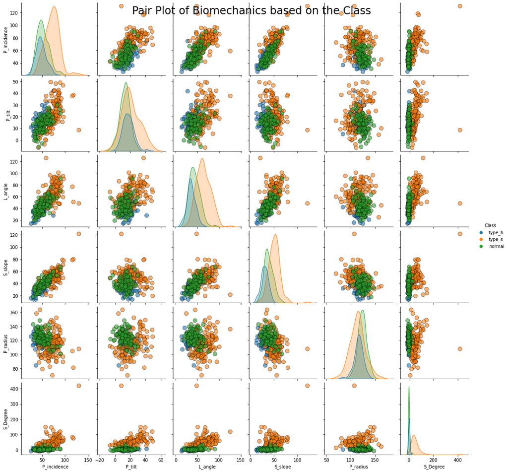

```python
sns.pairplot(biomechanics, hue = 'Class', diag_kind = 'kde',
             plot_kws = {'alpha': 0.6, 's': 80, 'edgecolor': 'k'}
             )
# Title
plt.suptitle('Pair Plot of Biomechanics based on the Class',
             size = 24);
```

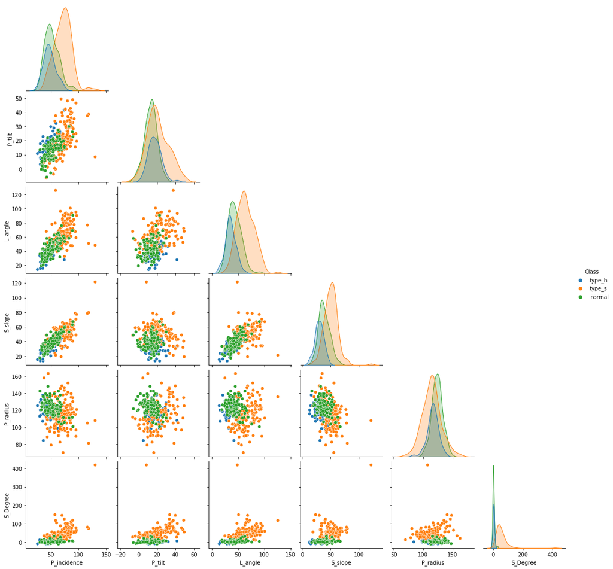

```python
#pd.plotting.scatter_matrix(biomechanics, c=biomechanics['Class'], figsize=(12, 10))
sns.pairplot(biomechanics.iloc[:, :7], hue='Class', corner=True)
plt.show()
```

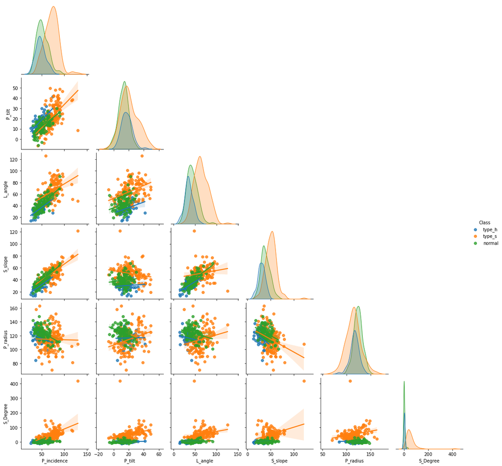

```python
sns.pairplot(biomechanics.iloc[:, :7], hue='Class', corner=True, kind='reg')
plt.show()
```

**Insights**

1. P_incidence has positive Linear correlation with L_angle and S_Slope
2. L_angle has positive Linear correlation with S_Slope
3. P_tilt does not have correlation with P_radius, S_Slope
4. S_Slope has little negative correlation with S_Slope
5. Class type_s has more distribution than any other types
6. Interms of S_Degree , type_S is distributed more, where as Normal and type_h are confined near to ero.

**Visualize a jointplot for ‘P_incidence’ and ‘S_slope’ and share insights. [2 Marks]**

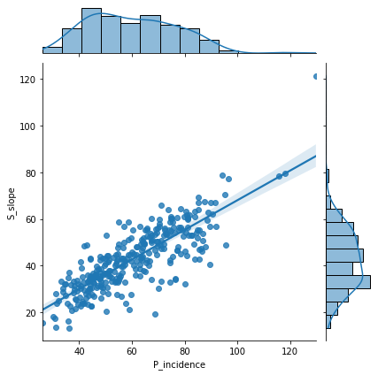

```python
# reg kind
sns.jointplot(x = "P_incidence", y = "S_slope",
              kind = "reg", data = biomechanics,
              dropna = True)

# show the plot
plt.show()
```

**e.Visualize a boxplot to check distribution of the features and share insights**

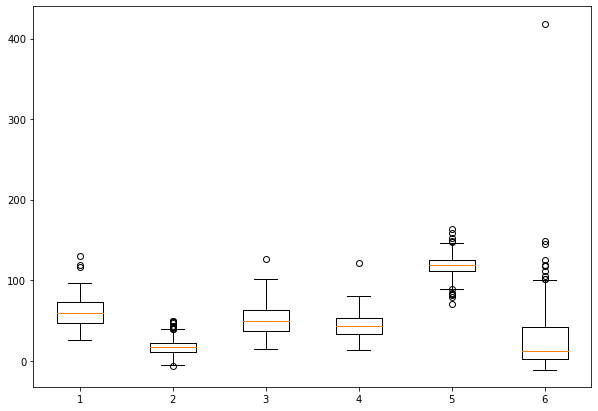

```python
fig = plt.figure(figsize =(10, 7))
biomechanics2= biomechanics.select_dtypes(exclude=['object'])

# Creating plot
plt.boxplot(biomechanics2)

# show plot
plt.show()
```

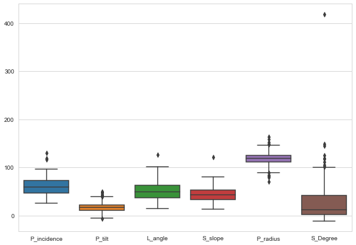

```python
sns.set_style("whitegrid")
fig = plt.figure(figsize =(10, 7))

sns.boxplot(data = biomechanics2)
```

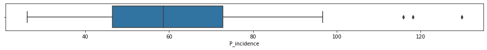

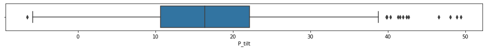

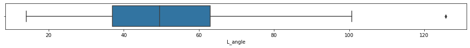

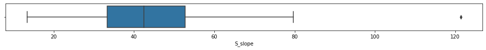

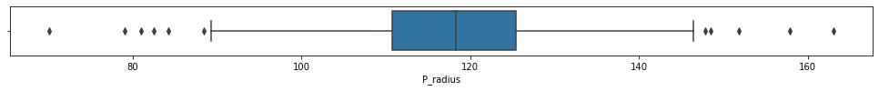

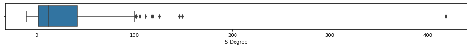

```python
import matplotlib.pyplot as plt
biomechanics1=biomechanics.select_dtypes(exclude=['object'])

for column in biomechanics1:
        plt.figure(figsize=(17,1))
        sns.boxplot(data=biomechanics1, x=column)
```

**Notes:** Box plots visually show the distribution of numerical data and skewness through displaying the data quartiles (or percentiles) and averages.

Box plots show the five-number summary of a set of data:  
including the minimum score, first (lower) quartile, median, third (upper) quartile, and maximum score. Left whisker Minimum, Right whisker Maximum, box represents lower Quartile, Median and Upper Quartile

**Note:** For this project we are going to build the model on KNN so, outlier will not have any impact.  
Hence not handling the outliers.

## 4. Model Building - 6

Understand the Distribution of Target variable

```python
biomechanics['Class'].value_counts()
```

```
type_s    150
normal    100
type_h     60
Name: Class, dtype: int64
```

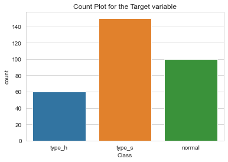

```python
# count plot on single categorical variable
sns.countplot(x ='Class', data = biomechanics)
plt.title("Count Plot for the Target variable")
# Show the plot
plt.show()
```

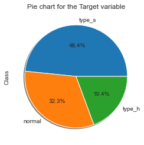

```python
import matplotlib.pyplot as plt
import seaborn as sns

#define data
labels = ['Class']

#define Seaborn color palette to use
colors = sns.color_palette('pastel')[0:5]
plt.title("Pie chart for the Target variable")
biomechanics['Class'].value_counts().plot.pie(autopct='%1.1f%%',shadow=True)
#biomechanics['Class'].value_counts().plot.pie(autopct='%.0f%%',shadow=True)
#create pie chart
#plt.pie(biomechanics, labels = labels, colors = colors, autopct='%.0f%%')
plt.show()
```

#### Observation

The Target varible the Class is not normally balanced  
Nearly 50% belongs to type S and, 32.3% is normal and Type_h is only 19.4%

**a. Split data into X and Y. [1 Marks]**

```python
# Split data into X and Y
# Create a separate dataframe consisting only of the features i.e independent attributes
X = biomechanics.drop(labels= "Class" , axis = 1)
y = biomechanics["Class"]
X.head()
```

|  | P_incidence | P_tilt | L_angle | S_slope | P_radius | S_Degree |
| --- | --- | --- | --- | --- | --- | --- |
| 0 | 63.027817 | 22.552586 | 39.609117 | 40.475232 | 98.672917 | -0.254400 |
| 1 | 39.056951 | 10.060991 | 25.015378 | 28.995960 | 114.405425 | 4.564259 |
| 2 | 68.832021 | 22.218482 | 50.092194 | 46.613539 | 105.985135 | -3.530317 |
| 3 | 69.297008 | 24.652878 | 44.311238 | 44.644130 | 101.868495 | 11.211523 |
| 4 | 49.712859 | 9.652075 | 28.317406 | 40.060784 | 108.168725 | 7.918501 |

```python
y.head()
```

```
0    type_h
1    type_h
2    type_h
3    type_h
4    type_h
Name: Class, dtype: object
```

```python
# convert the features into z scores as we do not know what units / scales were used and store them in new dataframe
# It is always adviced to scale numeric attributes in models that calculate distances.

XScaled  = X.apply(zscore)  # convert all attributes to Z scale

XScaled.describe().T
```

|  | count | mean | std | min | 25% | 50% | 75% | max |
| --- | --- | --- | --- | --- | --- | --- | --- | --- |
| P_incidence | 310.0 | -2.141656e-16 | 1.001617 | -1.996010 | -0.817398 | -0.104925 | 0.719464 | 4.029206 |
| P_tilt | 310.0 | 2.027052e-16 | 1.001617 | -2.411664 | -0.688114 | -0.118606 | 0.458116 | 3.191402 |
| L_angle | 310.0 | 3.527644e-16 | 1.001617 | -2.047652 | -0.806027 | -0.127862 | 0.597549 | 3.984615 |
| S_slope | 310.0 | -2.077191e-16 | 1.001617 | -2.207741 | -0.716842 | -0.040960 | 0.726941 | 5.855771 |
| P_radius | 310.0 | 5.121351e-16 | 1.001617 | -3.597963 | -0.542383 | 0.026138 | 0.567621 | 3.395818 |
| S_Degree | 310.0 | 2.184632e-16 | 1.001617 | -0.996172 | -0.658507 | -0.387450 | 0.399768 | 10.460350 |

**b. Split data into train and test with 80:20 proportion. [1 Marks]**

```python
# Split X and y into training and test set in 80:20 ratio
X_train, X_test, y_train, y_test = train_test_split(XScaled, y, test_size=0.20, random_state=42)
```

```python
display(X_train.shape, X_test.shape, y_train.shape, y_test.shape)
```

```
(248, 6)
```

```
(62, 6)
```

```
(248,)
```

```
(62,)
```

**c. Train a Supervised Learning Classification base model using KNN classifier.**[2 Marks]

```python
# KNN Model after scaling the features without hyperparameter tuning
knn = KNeighborsClassifier(n_neighbors = 5)
knn.fit(X_train,y_train)
```

```
KNeighborsClassifier()
```

**d.Print all the possible classification metrics for both train and test data.**

```python
print('k-Nearest Neighbor Classifier Scores after Scaling without Hyperparameter Tuning\n\n')
print('k-NN accuracy for train set: {0:.3f}'.format(knn.score(X_train, y_train)))
print('k-NN accuracy for test set: {0:.3f}'.format(knn.score(X_test, y_test)))

y_true, y_pred = y_test, knn.predict(X_test)

# Classification Report
print('\n{}'.format(classification_report(y_true, y_pred)))

# Confusion Matrix
cm = confusion_matrix(y_true, y_pred)
print('\nConfusion Matrix:\n', cm)

# Accuracy Score
auc = accuracy_score(y_true, y_pred)
print('\nAccuracy Score:\n', auc.round(3))
```

```
k-Nearest Neighbor Classifier Scores after Scaling without Hyperparameter Tuning


k-NN accuracy for train set: 0.847
k-NN accuracy for test set: 0.806

              precision    recall  f1-score   support

      normal       0.70      0.78      0.74        18
      type_h       0.60      0.50      0.55        12
      type_s       0.94      0.94      0.94        32

    accuracy                           0.81        62
   macro avg       0.75      0.74      0.74        62
weighted avg       0.80      0.81      0.80        62


Confusion Matrix:
 [[14  3  1]
 [ 5  6  1]
 [ 1  1 30]]

Accuracy Score:
 0.806
```

For the purpose of multiclass classifcation trying to encode the categorical features and target value Biomechanics has only the class as categorical

```python
from sklearn import metrics

print("Confusion Matrix")
cm=metrics.confusion_matrix(y_test, y_pred, labels=["type_s","type_h","normal"])
print(cm)
```

```
Confusion Matrix
[[30  1  1]
 [ 1  6  5]
 [ 1  3 14]]
```

```
Confusion Matrix
```

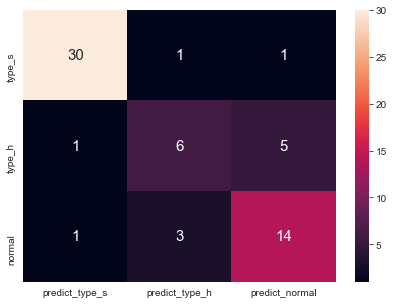

```python
# calculate accuracy measures and confusion matrix
from sklearn import metrics

print("Confusion Matrix")
cm=metrics.confusion_matrix(y_test, y_pred, labels=["type_s","type_h","normal"])
df_cm = pd.DataFrame(cm, index = [i for i in ["type_s","type_h","normal"]],
                  columns = [i for i in ["predict_type_s","predict_type_h","predict_normal"]])
plt.figure(figsize = (7,5))
sns.heatmap(df_cm, annot=True, fmt='g', annot_kws={'size':15})
```

```python
scores =[]
for k in range(1,50):
    NNH = KNeighborsClassifier(n_neighbors = k, weights = 'distance' )
    NNH.fit(X_train, y_train)
    scores.append(NNH.score(X_test, y_test))
```

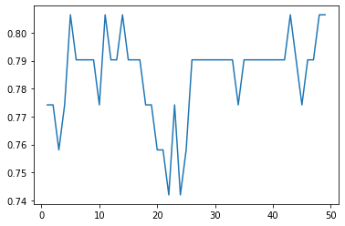

```python
plt.plot(range(1,50),scores)
```

### 5. Performance Improvement: 4

### 1.Rescaling to improve the performance

**Label encoding the Target values**

```python
from sklearn.preprocessing import OrdinalEncoder, LabelEncoder
#encoding categorical features and target variable

#Create copy of dataset.
df_model = biomechanics.copy()

encoder = OrdinalEncoder()
features=['P_incidence','P_tilt','L_angle','S_slope','P_radius','S_Degree']
data_encoded = encoder.fit_transform(df_model[features])
biomech_df_encoded = pd.DataFrame(data_encoded, columns=features)
encoder = LabelEncoder()
target_encoded = encoder.fit_transform(biomechanics['Class'])
biomech_df_encoded['Class'] = target_encoded
biomech_df_encoded.head()
```

|  | P_incidence | P_tilt | L_angle | S_slope | P_radius | S_Degree | Class |
| --- | --- | --- | --- | --- | --- | --- | --- |
| 0 | 172.0 | 236.0 | 79.0 | 126.0 | 26.0 | 55.0 | 1 |
| 1 | 28.0 | 69.0 | 10.0 | 42.0 | 108.0 | 108.0 | 1 |
| 2 | 209.0 | 233.0 | 137.0 | 172.0 | 51.0 | 18.0 | 1 |
| 3 | 211.0 | 250.0 | 109.0 | 167.0 | 35.0 | 153.0 | 1 |
| 4 | 98.0 | 61.0 | 21.0 | 124.0 | 61.0 | 141.0 | 1 |

```python
biomech_df_encoded['Class'].value_counts()
```

```
2    150
0    100
1     60
Name: Class, dtype: int64
```

#### Implement Scaler

```python
from sklearn.preprocessing import StandardScaler
scaler = StandardScaler()
#Rescaling features P_incidence, P_tilt, L_angle, S_Sclope, P_radius and S_Degree.
features = [['P_incidence','P_tilt','L_angle','S_slope','P_radius','S_Degree']]

for feature in features:
    biomech_df_encoded[feature] = scaler.fit_transform(biomech_df_encoded[feature])
```

#### Split Scaled data into X and Y

```python
#Create x and y variable
X = biomech_df_encoded.drop(columns=['Class'])
y = biomech_df_encoded['Class']
```

```python
#### Split the Train and Test Data
```

```python
X_train, X_test, y_train, y_test = train_test_split(X, y, test_size=0.20, random_state=42)
```

#### Build the Model and Verify the Accuracy after Scaling

```python
# KNN Model after scaling the features without hyperparameter tuning
knn = KNeighborsClassifier(n_neighbors = 5)
knn.fit(X_train,y_train)
```

```
KNeighborsClassifier()
```

```python
print('k-Nearest Neighbor Classifier Scores after Scaling With Scaler\n\n')
print('k-NN accuracy for train set: {0:.3f}'.format(knn.score(X_train, y_train)))
print('k-NN accuracy for test set: {0:.3f}'.format(knn.score(X_test, y_test)))

y_true, y_pred = y_test, knn.predict(X_test)

# Classification Report
print('\n{}'.format(classification_report(y_true, y_pred)))

# Confusion Matrix
cm = confusion_matrix(y_true, y_pred)
print('\nConfusion Matrix:\n', cm)

# Accuracy Score
auc = accuracy_score(y_true, y_pred)
print('\nAccuracy Score:\n', auc.round(3))
```

```
k-Nearest Neighbor Classifier Scores after Scaling With Scaler


k-NN accuracy for train set: 0.863
k-NN accuracy for test set: 0.839

              precision    recall  f1-score   support

           0       0.78      0.78      0.78        18
           1       0.67      0.67      0.67        12
           2       0.94      0.94      0.94        32

    accuracy                           0.84        62
   macro avg       0.79      0.79      0.79        62
weighted avg       0.84      0.84      0.84        62


Confusion Matrix:
 [[14  3  1]
 [ 3  8  1]
 [ 1  1 30]]

Accuracy Score:
 0.839
```

#### Accuracy Score Before Scaling

k-NN accuracy for train set: 0.847 k-NN accuracy for test set: 0.806

#### Accuracy Score After Scaling

k-NN accuracy for train set: 0.863 k-NN accuracy for test set: 0.839

### 2. Robust Scaling to improve Performance

Rescaling is using Robust Scaling to handle the presences of outliers in our data.

```python
from sklearn.preprocessing import RobustScaler
scaler = RobustScaler()
#Rescaling features P_incidence, P_tilt, L_angle, S_Sclope, P_radius and S_Degree.
features = [['P_incidence','P_tilt','L_angle','S_slope','P_radius','S_Degree']]

for feature in features:
    biomech_df_encoded[feature] = scaler.fit_transform(biomech_df_encoded[feature])
```

```python
#Create x and y variable
X = biomech_df_encoded.drop(columns=['Class'])
y = biomech_df_encoded['Class']
X_train, X_test, y_train, y_test = train_test_split(X, y, test_size=0.20, random_state=42)
# KNN Model after scaling the features without hyperparameter tuning
knn = KNeighborsClassifier(n_neighbors = 5)
knn.fit(X_train,y_train)
```

```
KNeighborsClassifier()
```

```python
print('k-Nearest Neighbor Classifier Scores after Scaling With Robust Scaler\n\n')
print('k-NN accuracy for train set: {0:.3f}'.format(knn.score(X_train, y_train)))
print('k-NN accuracy for test set: {0:.3f}'.format(knn.score(X_test, y_test)))

y_true, y_pred = y_test, knn.predict(X_test)

# Classification Report
print('\n{}'.format(classification_report(y_true, y_pred)))

# Confusion Matrix
cm = confusion_matrix(y_true, y_pred)
print('\nConfusion Matrix:\n', cm)

# Accuracy Score
auc = accuracy_score(y_true, y_pred)
print('\nAccuracy Score:\n', auc.round(3))
```

```
k-Nearest Neighbor Classifier Scores after Scaling With Robust Scaler


k-NN accuracy for train set: 0.859
k-NN accuracy for test set: 0.823

              precision    recall  f1-score   support

           0       0.76      0.72      0.74        18
           1       0.62      0.67      0.64        12
           2       0.94      0.94      0.94        32

    accuracy                           0.82        62
   macro avg       0.77      0.78      0.77        62
weighted avg       0.82      0.82      0.82        62


Confusion Matrix:
 [[13  4  1]
 [ 3  8  1]
 [ 1  1 30]]

Accuracy Score:
 0.823
```

#### Observation:

#### 1. Accuracy Score Before Scaling

k-NN accuracy for train set: 0.847  
k-NN accuracy for test set: 0.806

#### 2. Accuracy Score After Scaling

k-NN accuracy for train set: 0.863  
k-NN accuracy for test set: 0.839

#### 3.Accuracy Score After Robust Scaling

k-NN accuracy for train set: 0.859  
k-NN accuracy for test set: 0.823

Accuracy Score got reducedd than the Scaling

### 3. MinMax Scaling to improve Performance

```python
from sklearn.preprocessing import MinMaxScaler
scaler = MinMaxScaler()
#Rescaling features P_incidence, P_tilt, L_angle, S_Sclope, P_radius and S_Degree.
features = [['P_incidence','P_tilt','L_angle','S_slope','P_radius','S_Degree']]

for feature in features:
    biomech_df_encoded[feature] = scaler.fit_transform(biomech_df_encoded[feature])
```

```python
#Create x and y variable
X = biomech_df_encoded.drop(columns=['Class'])
y = biomech_df_encoded['Class']
X_train, X_test, y_train, y_test = train_test_split(X, y, test_size=0.20, random_state=42)
# KNN Model after scaling the features without hyperparameter tuning
knn = KNeighborsClassifier(n_neighbors = 5)
knn.fit(X_train,y_train)
```

```
KNeighborsClassifier()
```

```python
print('k-Nearest Neighbor Classifier Scores after MinMaxScaler\n\n')
print('k-NN accuracy for train set: {0:.3f}'.format(knn.score(X_train, y_train)))
print('k-NN accuracy for test set: {0:.3f}'.format(knn.score(X_test, y_test)))

y_true, y_pred = y_test, knn.predict(X_test)

# Classification Report
print('\n{}'.format(classification_report(y_true, y_pred)))

# Confusion Matrix
cm = confusion_matrix(y_true, y_pred)
print('\nConfusion Matrix:\n', cm)

# Accuracy Score
auc = accuracy_score(y_true, y_pred)
print('\nAccuracy Score:\n', auc.round(3))
```

```
k-Nearest Neighbor Classifier Scores after MinMaxScaler


k-NN accuracy for train set: 0.863
k-NN accuracy for test set: 0.839

              precision    recall  f1-score   support

           0       0.78      0.78      0.78        18
           1       0.67      0.67      0.67        12
           2       0.94      0.94      0.94        32

    accuracy                           0.84        62
   macro avg       0.79      0.79      0.79        62
weighted avg       0.84      0.84      0.84        62


Confusion Matrix:
 [[14  3  1]
 [ 3  8  1]
 [ 1  1 30]]

Accuracy Score:
 0.839
```

#### b. Clearly showcase improvement in performance achieved.

#### 1.Accuracy Score Before Scaling

k-NN accuracy for train set: 0.847  
k-NN accuracy for test set: 0.806

#### 2.Accuracy Score After Scaling

k-NN accuracy for train set: **0.863**  
k-NN accuracy for test set: **0.839**

#### 3.Accuracy Score After Robust Scaling

k-NN accuracy for train set: 0.859  
k-NN accuracy for test set: 0.823

#### 4.Accuracy Score After Min Max Scaling

k-NN accuracy for train set: **0.863**  
k-NN accuracy for test set: **0.839**

#### Observation:

The accuracy score for both Test and Train data has improved by the Scaling and MinMax Scaling by 2%(TrainSet) by 3%(TestSet).  
Hence improvement in model performance is achieved

#### c.Clearly state which parameters contributed most to improve model performance. What could be the probable reason? [1 Marks]

#### Observation:

Machine learning learning models usually learn a mapping from input variables to target or output variable. But the scale and data distribution differs for each variable. The input variables may have different units (degrees, centimetes, years etc). Hence these have different scales of measurement. This would increase the difficulty of modeling. Because of this model may suffer from poor performance high generalization error.

In this biomechanic data set, This simple preprocessing of the features by Scaling improved the performance considerably

# PART 2

#### Context

A bank X is on a massive digital transformation for all its departments. Bank has a growing customer base whee majority of them are liability customers (depositors) vs borrowers (asset customers). The bank is interested in expanding the borrowers base rapidly to bring in more business via loan interests. A campaign that the bank ran in last quarter showed an average single digit conversion rate. Digital transformation being the core strength of the business strategy, marketing department wants to devise effective campaigns with better target marketing to increase the conversion ratio to double digit with same budget as per last campaign.

#### Data Description:

The data consists of the following attributes:

```
1. ID: Customer ID<br>
2. Age Customer’s approximate age.<br>
3. CustomerSince: Customer of the bank since. [unit is masked]<br>
4. HighestSpend: Customer’s highest spend so far in one transaction. [unit is masked]<br>
5. ZipCode: Customer’s zip code.<br>
6. HiddenScore: A score associated to the customer which is masked by the bank as an IP.<br>
7. MonthlyAverageSpend: Customer’s monthly average spend so far. [unit is masked]<br>
8. Level: A level associated to the customer which is masked by the bank as an IP.<br>
9. Mortgage: Customer’s mortgage. [unit is masked]<br>
10. Security: Customer’s security asset with the bank. [unit is masked]<br>
11. FixedDepositAccount: Customer’s fixed deposit account with the bank. [unit is masked]<br>
12. InternetBanking: if the customer uses internet banking.<br>
13. CreditCard: if the customer uses bank’s credit card.<br>
14. LoanOnCard: if the customer has a loan on credit card.
```

#### Project Objective:

Build a Machine Learning model to perform focused marketing by predicting the potential customers who will convert using the historical dataset.

## 1. Data Understanding and Preparation: 5

**a. Read both the Datasets ‘Data1’ and ‘Data2’ as DataFrame and store them into two separate variables.**

```python
data1=pd.read_csv("data1.csv")
data2=pd.read_csv("data2.csv")
data1.head()
```

|  | ID | Age | CustomerSince | HighestSpend | ZipCode | HiddenScore | MonthlyAverageSpend | Level |
| --- | --- | --- | --- | --- | --- | --- | --- | --- |
| 0 | 1 | 25 | 1 | 49 | 91107 | 4 | 1.6 | 1 |
| 1 | 2 | 45 | 19 | 34 | 90089 | 3 | 1.5 | 1 |
| 2 | 3 | 39 | 15 | 11 | 94720 | 1 | 1.0 | 1 |
| 3 | 4 | 35 | 9 | 100 | 94112 | 1 | 2.7 | 2 |
| 4 | 5 | 35 | 8 | 45 | 91330 | 4 | 1.0 | 2 |

```python
data2.head()
```

|  | ID | Mortgage | Security | FixedDepositAccount | InternetBanking | CreditCard | LoanOnCard |
| --- | --- | --- | --- | --- | --- | --- | --- |
| 0 | 1 | 0 | 1 | 0 | 0 | 0 | NaN |
| 1 | 2 | 0 | 1 | 0 | 0 | 0 | NaN |
| 2 | 3 | 0 | 0 | 0 | 0 | 0 | NaN |
| 3 | 4 | 0 | 0 | 0 | 0 | 0 | NaN |
| 4 | 5 | 0 | 0 | 0 | 0 | 1 | NaN |

**b. Print shape and Column Names and DataTypes of both the Dataframes. [1 Mark]**

```python
data1.shape
```

```
(5000, 8)
```

```python
data2.shape
```

```
(5000, 7)
```

```python
# column names of data 1
data1.columns
```

```
Index(['ID', 'Age', 'CustomerSince', 'HighestSpend', 'ZipCode', 'HiddenScore',
       'MonthlyAverageSpend', 'Level'],
      dtype='object')
```

```python
#Column names of data 2
data2.columns
```

```
Index(['ID', 'Mortgage', 'Security', 'FixedDepositAccount', 'InternetBanking',
       'CreditCard', 'LoanOnCard'],
      dtype='object')
```

```python
data1.dtypes
```

```
ID                       int64
Age                      int64
CustomerSince            int64
HighestSpend             int64
ZipCode                  int64
HiddenScore              int64
MonthlyAverageSpend    float64
Level                    int64
dtype: object
```

```python
data1.dtypes
```

[output not shown]

```
ID                       int64
Age                      int64
CustomerSince            int64
HighestSpend             int64
ZipCode                  int64
HiddenScore              int64
MonthlyAverageSpend    float64
Level                    int64
dtype: object
```

**c. Merge both the Dataframes on ‘ID’ feature to form a single DataFrame [2 Marks]**

```python
customerdata = pd.merge(data1,data2, on="ID")
customerdata.head()
```

|  | ID | Age | CustomerSince | HighestSpend | ZipCode | HiddenScore | MonthlyAverageSpend | Level | Mortgage | Security | FixedDepositAccount | InternetBanking | CreditCard | LoanOnCard |
| --- | --- | --- | --- | --- | --- | --- | --- | --- | --- | --- | --- | --- | --- | --- |
| 0 | 1 | 25 | 1 | 49 | 91107 | 4 | 1.6 | 1 | 0 | 1 | 0 | 0 | 0 | NaN |
| 1 | 2 | 45 | 19 | 34 | 90089 | 3 | 1.5 | 1 | 0 | 1 | 0 | 0 | 0 | NaN |
| 2 | 3 | 39 | 15 | 11 | 94720 | 1 | 1.0 | 1 | 0 | 0 | 0 | 0 | 0 | NaN |
| 3 | 4 | 35 | 9 | 100 | 94112 | 1 | 2.7 | 2 | 0 | 0 | 0 | 0 | 0 | NaN |
| 4 | 5 | 35 | 8 | 45 | 91330 | 4 | 1.0 | 2 | 0 | 0 | 0 | 0 | 1 | NaN |

```python
customerdata.shape
```

```
(5000, 14)
```

**d. Change Datatype of below features to ‘Object’ [1 Mark]**

‘CreditCard’, ‘InternetBanking’, ‘FixedDepositAccount’, ‘Security’, ‘Level’, ‘HiddenScore’. [Reason behind performing this operation:- Values in these features are binary i.e. 1/0. But DataType is ‘int’/’float’ which is not expected.]**

```python
customerdata.dtypes
```

```
ID                       int64
Age                      int64
CustomerSince            int64
HighestSpend             int64
ZipCode                  int64
HiddenScore              int64
MonthlyAverageSpend    float64
Level                    int64
Mortgage                 int64
Security                 int64
FixedDepositAccount      int64
InternetBanking          int64
CreditCard               int64
LoanOnCard             float64
dtype: object
```

```python
#To change datatype to Object
customerdata['CreditCard']= customerdata.CreditCard.astype(object)
customerdata['InternetBanking']= customerdata.InternetBanking.astype(object)
customerdata['FixedDepositAccount']= customerdata.FixedDepositAccount.astype(object)
customerdata['Security']= customerdata.Security.astype(object)
customerdata['Level']= customerdata.Level.astype(object)
customerdata['HiddenScore']= customerdata.HiddenScore.astype(object)
```

```python
customerdata.dtypes
```

```
ID                       int64
Age                      int64
CustomerSince            int64
HighestSpend             int64
ZipCode                  int64
HiddenScore             object
MonthlyAverageSpend    float64
Level                   object
Mortgage                 int64
Security                object
FixedDepositAccount     object
InternetBanking         object
CreditCard              object
LoanOnCard             float64
dtype: object
```

## 2. Data Exploration and Analysis: 5

**a. Visualize distribution of Target variable ‘LoanOnCard’ and clearly share insights. [2 Marks]**

```python
customerdata['LoanOnCard'].describe()
```

```
count    4980.000000
mean        0.096386
std         0.295149
min         0.000000
25%         0.000000
50%         0.000000
75%         0.000000
max         1.000000
Name: LoanOnCard, dtype: float64
```

```python
customerdata['LoanOnCard'].head(10)
```

```
0    NaN
1    NaN
2    NaN
3    NaN
4    NaN
5    NaN
6    NaN
7    NaN
8    NaN
9    1.0
Name: LoanOnCard, dtype: float64
```

```python
customerdata['LoanOnCard'].value_counts()
```

```
0.0    4500
1.0     480
Name: LoanOnCard, dtype: int64
```

#### Comments:

Out of 5000, 20 data sets are not having value.

```python
customerdata.describe().T
```

|  | count | mean | std | min | 25% | 50% | 75% | max |
| --- | --- | --- | --- | --- | --- | --- | --- | --- |
| ID | 5000.0 | 2500.500000 | 1443.520003 | 1.0 | 1250.75 | 2500.5 | 3750.25 | 5000.0 |
| Age | 5000.0 | 45.338400 | 11.463166 | 23.0 | 35.00 | 45.0 | 55.00 | 67.0 |
| CustomerSince | 5000.0 | 20.104600 | 11.467954 | -3.0 | 10.00 | 20.0 | 30.00 | 43.0 |
| HighestSpend | 5000.0 | 73.774200 | 46.033729 | 8.0 | 39.00 | 64.0 | 98.00 | 224.0 |
| ZipCode | 5000.0 | 93152.503000 | 2121.852197 | 9307.0 | 91911.00 | 93437.0 | 94608.00 | 96651.0 |
| MonthlyAverageSpend | 5000.0 | 1.937938 | 1.747659 | 0.0 | 0.70 | 1.5 | 2.50 | 10.0 |
| Mortgage | 5000.0 | 56.498800 | 101.713802 | 0.0 | 0.00 | 0.0 | 101.00 | 635.0 |
| LoanOnCard | 4980.0 | 0.096386 | 0.295149 | 0.0 | 0.00 | 0.0 | 0.00 | 1.0 |

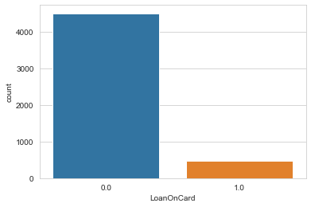

```python
#visualize the LoanOnCard
sns.countplot(x='LoanOnCard',data=customerdata)
plt.show()
```

**Insights:** LoanOnCard -is 0 for 4500 customers and 1 for 480 customers

**b.Check the percentage of missing values and impute if required. [1 Mark]**

```python
# For missing data
percent_missing = customerdata.isnull().sum() * 100 / len(customerdata)
missing_value_df = pd.DataFrame({'column_name': customerdata.columns,
                                 'percent_missing': percent_missing})
missing_value_df
```

|  | column_name | percent_missing |
| --- | --- | --- |
| ID | ID | 0.0 |
| Age | Age | 0.0 |
| CustomerSince | CustomerSince | 0.0 |
| HighestSpend | HighestSpend | 0.0 |
| ZipCode | ZipCode | 0.0 |
| HiddenScore | HiddenScore | 0.0 |
| MonthlyAverageSpend | MonthlyAverageSpend | 0.0 |
| Level | Level | 0.0 |
| Mortgage | Mortgage | 0.0 |
| Security | Security | 0.0 |
| FixedDepositAccount | FixedDepositAccount | 0.0 |
| InternetBanking | InternetBanking | 0.0 |
| CreditCard | CreditCard | 0.0 |
| LoanOnCard | LoanOnCard | 0.4 |

#### Observation

Missing value is in LoanOnCard, imputing value will make the wrong interpretation. Being 0.4 % is small, No imputation is required and so decided to drop the data having NAN value

```python
customerdata.isnull().sum()
```

```
ID                      0
Age                     0
CustomerSince           0
HighestSpend            0
ZipCode                 0
HiddenScore             0
MonthlyAverageSpend     0
Level                   0
Mortgage                0
Security                0
FixedDepositAccount     0
InternetBanking         0
CreditCard              0
LoanOnCard             20
dtype: int64
```

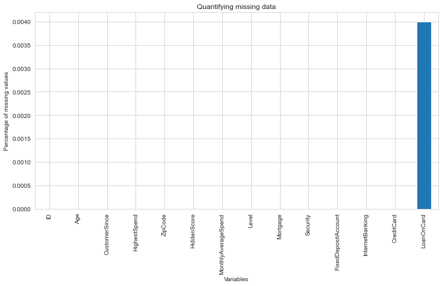

```python
customerdata.isnull().mean().plot.bar(figsize=(12,6))
plt.ylabel('Percentage of missing values')
plt.xlabel('Variables')
plt.title('Quantifying missing data')
```

#### Removing the 20 records for which the data is not available

```python
customerdata.dropna(inplace=True)
customerdata.shape
```

```
(4980, 14)
```

**c.Check for unexpected values in each categorical variable and impute with best suitable value**

#### Understanding the values of categorical variables

```python
categoricalColumns=['HiddenScore','Level','Security','FixedDepositAccount','InternetBanking','CreditCard','LoanOnCard']
for col in customerdata[categoricalColumns]:
    print(col)
    print(customerdata[col].value_counts())
```

```
HiddenScore
1    1466
2    1293
4    1215
3    1006
Name: HiddenScore, dtype: int64
Level
1    2089
3    1496
2    1395
Name: Level, dtype: int64
Security
0    4460
1     520
Name: Security, dtype: int64
FixedDepositAccount
0    4678
1     302
Name: FixedDepositAccount, dtype: int64
InternetBanking
1    2974
0    2006
Name: InternetBanking, dtype: int64
CreditCard
0    3514
1    1466
Name: CreditCard, dtype: int64
LoanOnCard
0.0    4500
1.0     480
Name: LoanOnCard, dtype: int64
```

#### Observation:

```python
customerdata['LoanOnCard'].value_counts()
```

```
0.0    4500
1.0     480
Name: LoanOnCard, dtype: int64
```

```python
customerdata['LoanOnCard']=customerdata.LoanOnCard.astype(str)
```

```python
customerdata['LoanOnCard'].value_counts()
```

```
0.0    4500
1.0     480
Name: LoanOnCard, dtype: int64
```

```python
customerdata['LoanOnCard']=customerdata['LoanOnCard'].replace('0.0', 0)
customerdata['LoanOnCard']=customerdata['LoanOnCard'].replace('1.0', 1)
```

```python
customerdata['LoanOnCard'].value_counts()
```

```
0    4500
1     480
Name: LoanOnCard, dtype: int64
```

```python
customerdata['LoanOnCard']=customerdata.LoanOnCard.astype('category')
```

```python
for col in customerdata[categoricalColumns]:
    print(col)
    print(customerdata[col].value_counts())
```

```
HiddenScore
1    1466
2    1293
4    1215
3    1006
Name: HiddenScore, dtype: int64
Level
1    2089
3    1496
2    1395
Name: Level, dtype: int64
Security
0    4460
1     520
Name: Security, dtype: int64
FixedDepositAccount
0    4678
1     302
Name: FixedDepositAccount, dtype: int64
InternetBanking
1    2974
0    2006
Name: InternetBanking, dtype: int64
CreditCard
0    3514
1    1466
Name: CreditCard, dtype: int64
LoanOnCard
0    4500
1     480
Name: LoanOnCard, dtype: int64
```

```python
#copying the data to another dataframe to do the cleaning operation
cdata =customerdata.copy(deep=True)
cdata.head()
```

|  | ID | Age | CustomerSince | HighestSpend | ZipCode | HiddenScore | MonthlyAverageSpend | Level | Mortgage | Security | FixedDepositAccount | InternetBanking | CreditCard | LoanOnCard |
| --- | --- | --- | --- | --- | --- | --- | --- | --- | --- | --- | --- | --- | --- | --- |
| 9 | 10 | 34 | 9 | 180 | 93023 | 1 | 8.9 | 3 | 0 | 0 | 0 | 0 | 0 | 1 |
| 10 | 11 | 65 | 39 | 105 | 94710 | 4 | 2.4 | 3 | 0 | 0 | 0 | 0 | 0 | 0 |
| 11 | 12 | 29 | 5 | 45 | 90277 | 3 | 0.1 | 2 | 0 | 0 | 0 | 1 | 0 | 0 |
| 12 | 13 | 48 | 23 | 114 | 93106 | 2 | 3.8 | 3 | 0 | 1 | 0 | 0 | 0 | 0 |
| 13 | 14 | 59 | 32 | 40 | 94920 | 4 | 2.5 | 2 | 0 | 0 | 0 | 1 | 0 | 0 |

```python
cdata.shape
```

```
(4980, 14)
```

### Numeric Features

```python
customerdata.describe().T
```

|  | count | mean | std | min | 25% | 50% | 75% | max |
| --- | --- | --- | --- | --- | --- | --- | --- | --- |
| ID | 4980.0 | 2510.345382 | 1438.011129 | 10.0 | 1265.75 | 2510.5 | 3755.250 | 5000.0 |
| Age | 4980.0 | 45.352610 | 11.464212 | 23.0 | 35.00 | 45.0 | 55.000 | 67.0 |
| CustomerSince | 4980.0 | 20.117671 | 11.468716 | -3.0 | 10.00 | 20.0 | 30.000 | 43.0 |
| HighestSpend | 4980.0 | 73.852410 | 46.070090 | 8.0 | 39.00 | 64.0 | 98.000 | 224.0 |
| ZipCode | 4980.0 | 93152.420482 | 2123.660073 | 9307.0 | 91911.00 | 93407.0 | 94608.000 | 96651.0 |
| MonthlyAverageSpend | 4980.0 | 1.939536 | 1.750006 | 0.0 | 0.70 | 1.5 | 2.525 | 10.0 |
| Mortgage | 4980.0 | 56.589759 | 101.836758 | 0.0 | 0.00 | 0.0 | 101.000 | 635.0 |

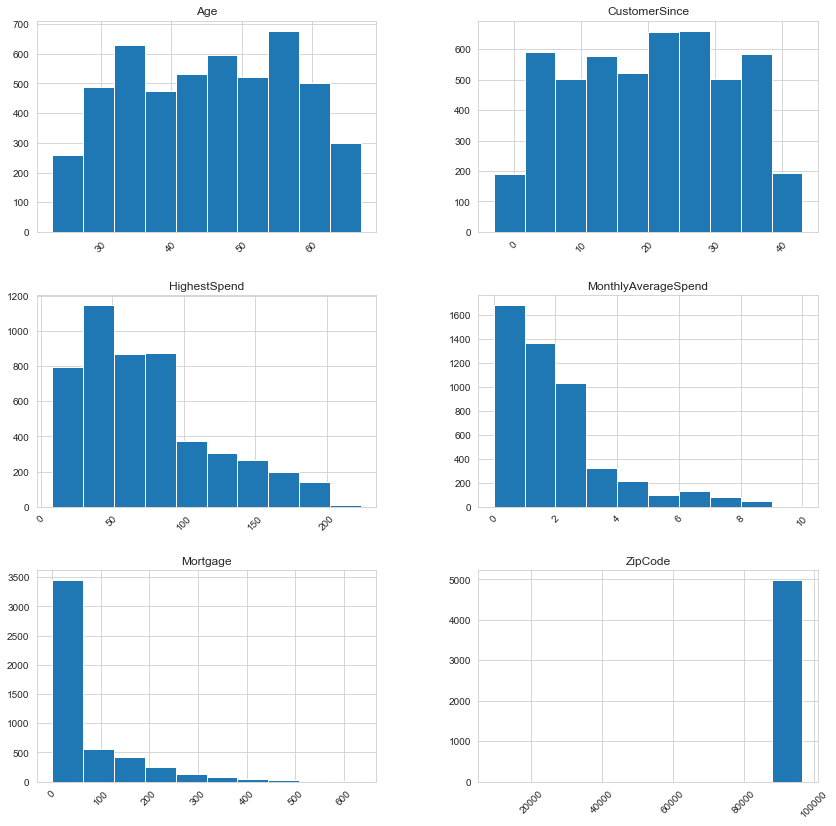

```python
exclude = ['ID','LoanOnCard']
#df.loc[:, df.columns.difference(exclude)].hist()
cdata.loc[:, cdata.columns.difference(exclude)].hist(figsize=(14,14), xrot=45)
plt.show()
```

#### Observation

We can infer from bar plots that

1. The customer base is mostly Medium age.(Age distributed from approximately 23 to 67. Data has medium aged people than very young or very old)
2. There are customers associated even around 40 years.)Customer since has -ve value, this can be corrected. As per this, there are customers from -3 to more than 40 years)
3. Highest spend is 224. More customers spends around 64(median) and its right skewed
4. Monthly average spend ranges from 0 to 10. Mean is 1.93 and its right skewed. So they are less spenders,
5. Morgage ranges from 0 to 635 and its right skewed

```python
customerdata['CustomerSince'].value_counts(bins=5,ascending=True)
```

```
(33.8, 43.0]                   780
(-3.0469999999999997, 6.2]     781
(6.2, 15.4]                   1080
(24.6, 33.8]                  1162
(15.4, 24.6]                  1177
Name: CustomerSince, dtype: int64
```

```python
dataLessThan0 = customerdata[customerdata['CustomerSince']<0]
len(dataLessThan0)
```

```
51
```

51 data are having customerSince value less than 0. which are unexpected. Assumption would be the from the time of calculation they might be few years before the year /period it is been calculated..So to rectify adding 3 to everydata

```python
customerdata['CustomerSince'] = customerdata['CustomerSince'] + 3
```

```python
print(customerdata.isnull().values.any())
```

```
False
```

```python
customerdata['CustomerSince'].describe().T
```

```
count    4980.000000
mean       23.117671
std        11.468716
min         0.000000
25%        13.000000
50%        23.000000
75%        33.000000
max        46.000000
Name: CustomerSince, dtype: float64
```

```python
customerdata.describe().T
```

|  | count | mean | std | min | 25% | 50% | 75% | max |
| --- | --- | --- | --- | --- | --- | --- | --- | --- |
| ID | 4980.0 | 2510.345382 | 1438.011129 | 10.0 | 1265.75 | 2510.5 | 3755.250 | 5000.0 |
| Age | 4980.0 | 45.352610 | 11.464212 | 23.0 | 35.00 | 45.0 | 55.000 | 67.0 |
| CustomerSince | 4980.0 | 23.117671 | 11.468716 | 0.0 | 13.00 | 23.0 | 33.000 | 46.0 |
| HighestSpend | 4980.0 | 73.852410 | 46.070090 | 8.0 | 39.00 | 64.0 | 98.000 | 224.0 |
| ZipCode | 4980.0 | 93152.420482 | 2123.660073 | 9307.0 | 91911.00 | 93407.0 | 94608.000 | 96651.0 |
| MonthlyAverageSpend | 4980.0 | 1.939536 | 1.750006 | 0.0 | 0.70 | 1.5 | 2.525 | 10.0 |
| Mortgage | 4980.0 | 56.589759 | 101.836758 | 0.0 | 0.00 | 0.0 | 101.000 | 635.0 |

#### Summary statistics of the categorical features

```python
customerdata.describe(include='object')
```

|  | HiddenScore | Level | Security | FixedDepositAccount | InternetBanking | CreditCard |
| --- | --- | --- | --- | --- | --- | --- |
| count | 4980 | 4980 | 4980 | 4980 | 4980 | 4980 |
| unique | 4 | 3 | 2 | 2 | 2 | 2 |
| top | 1 | 1 | 0 | 0 | 1 | 0 |
| freq | 1466 | 2089 | 4460 | 4678 | 2974 | 3514 |

#### Comments

All the categorical values have 2-4 unique values